# HW_1

Stanislav Sochynskyi

March 2, 2019

File import

```r
df<-read.csv("inputfile1.csv",sep=" ")
df
```

| time | account_a | account_b | account_c |
| --- | --- | --- | --- |
| 2007-09-01 | 8107.7949 | 4897.006 | 426.7283 |
| 2007-10-01 | 8020.9173 | 4897.006 | 871.2072 |
| 2007-11-01 | 8000.0569 | 4897.018 | 1026.6142 |
| 2007-12-01 | 7904.5107 | 4894.121 | 695.6800 |
| 2008-01-01 | 8341.8919 | 4893.317 | 895.9983 |
| 2008-02-01 | 8250.2362 | 4892.143 | 978.6201 |
| 2008-03-01 | 8032.8082 | 4889.841 | 362.8331 |
| 2008-04-01 | 8111.5728 | 4883.904 | 510.7856 |
| 2008-05-01 | 7725.0085 | 4878.344 | 238.4891 |
| 2008-06-01 | 7693.1446 | 4874.443 | 643.7213 |

[output cut: 110 more lines]

Task #1. Identify the data type of each column. Write the command and its corresponding output.

```r
print(class(df$time))
```

```
## [1] "factor"
```

```r
print(class(df$account_a))
```

```
## [1] "numeric"
```

```r
print(class(df$account_b))
```

```
## [1] "numeric"
```

```r
print(class(df$account_c))
```

```
## [1] "numeric"
```

Task #2. For each columnin dataset: a) Find unique values in case column is oftype factor;

```r
unique(df$time)
```

```
##   [1] 2007-09-01 2007-10-01 2007-11-01 2007-12-01 2008-01-01 2008-02-01
##   [7] 2008-03-01 2008-04-01 2008-05-01 2008-06-01 2008-07-01 2008-08-01
##  [13] 2008-09-01 2008-10-01 2008-11-01 2008-12-01 2009-01-01 2009-02-01
##  [19] 2009-03-01 2009-04-01 2009-05-01 2009-06-01 2009-07-01 2009-08-01
##  [25] 2009-09-01 2009-10-01 2009-11-01 2009-12-01 2010-01-01 2010-02-01
##  [31] 2010-03-01 2010-04-01 2010-05-01 2010-06-01 2010-07-01 2010-08-01
##  [37] 2010-09-01 2010-10-01 2010-11-01 2010-12-01 2011-01-01 2011-02-01
##  [43] 2011-03-01 2011-04-01 2011-05-01 2011-06-01 2011-07-01 2011-08-01
##  [49] 2011-09-01 2011-10-01 2011-11-01 2011-12-01 2012-01-01 2012-02-01
##  [55] 2012-03-01 2012-04-01 2012-05-01 2012-06-01 2012-07-01 2012-08-01
##  [61] 2012-09-01 2012-10-01 2012-11-01 2012-12-01 2013-01-01 2013-02-01
##  [67] 2013-03-01 2013-04-01 2013-05-01 2013-06-01 2013-07-01 2013-08-01
##  [73] 2013-09-01 2013-10-01 2013-11-01 2013-12-01 2014-01-01 2014-02-01
##  [79] 2014-03-01 2014-04-01 2014-05-01 2014-06-01 2014-07-01 2014-08-01
##  [85] 2014-09-01 2014-10-01 2014-11-01 2014-12-01 2015-01-01 2015-02-01
##  [91] 2015-03-01 2015-04-01 2015-05-01 2015-06-01 2015-07-01 2015-08-01
##  [97] 2015-09-01 2015-10-01 2015-11-01 2015-12-01 2016-01-01 2016-02-01
## [103] 2016-03-01 2016-04-01 2016-05-01 2016-06-01 2016-07-01 2016-08-01
## [109] 2016-09-01 2016-10-01 2016-11-01 2016-12-01 2017-01-01 2017-02-01
## [115] 2017-03-01 2017-04-01 2017-05-01 2017-06-01 2017-07-01 2017-08-01
## 120 Levels: 2007-09-01 2007-10-01 2007-11-01 2007-12-01 ... 2017-08-01
```

2. Find ranges(minimum and maximum)if column belongs to numeric type: For column “account_a”.

```r
min(df$account_a)
```

```
## [1] 0
```

```r
max(df$account_a)
```

```
## [1] 8341.892
```

```r
range(df$account_a)
```

```
## [1]    0.000 8341.892
```

For column “account_b”.

```r
min(df$account_b)
```

```
## [1] 4873.24
```

```r
max(df$account_b)
```

```
## [1] 8417.935
```

```r
range(df$account_b)
```

```
## [1] 4873.240 8417.935
```

For column “account_c”.

```r
min(df$account_c)
```

```
## [1] 217.896
```

```r
max(df$account_c)
```

```
## [1] 1179.125
```

```r
range(df$account_c)
```

```
## [1]  217.896 1179.125
```

Task #3. Build 3 scatter plots in order to find correlation among threebank accounts. Is there any relation between any 2 bank accounts?

We need to load “ggplot2” library for this task.

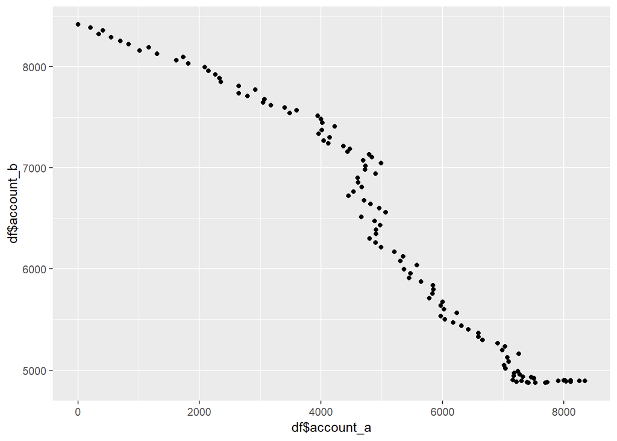

```r
library("ggplot2")
ggplot(df)+
  geom_point(aes(x=df$account_a,y=df$account_b))
```

```r
cor(df$account_a, df$account_b)
```

```
## [1] -0.9671627
```

Negative correlation between “account_a”" and “account_b”" is observed in the grap. Function “cor” showed “-0.9671627” which proves our observation from the scatter plot.

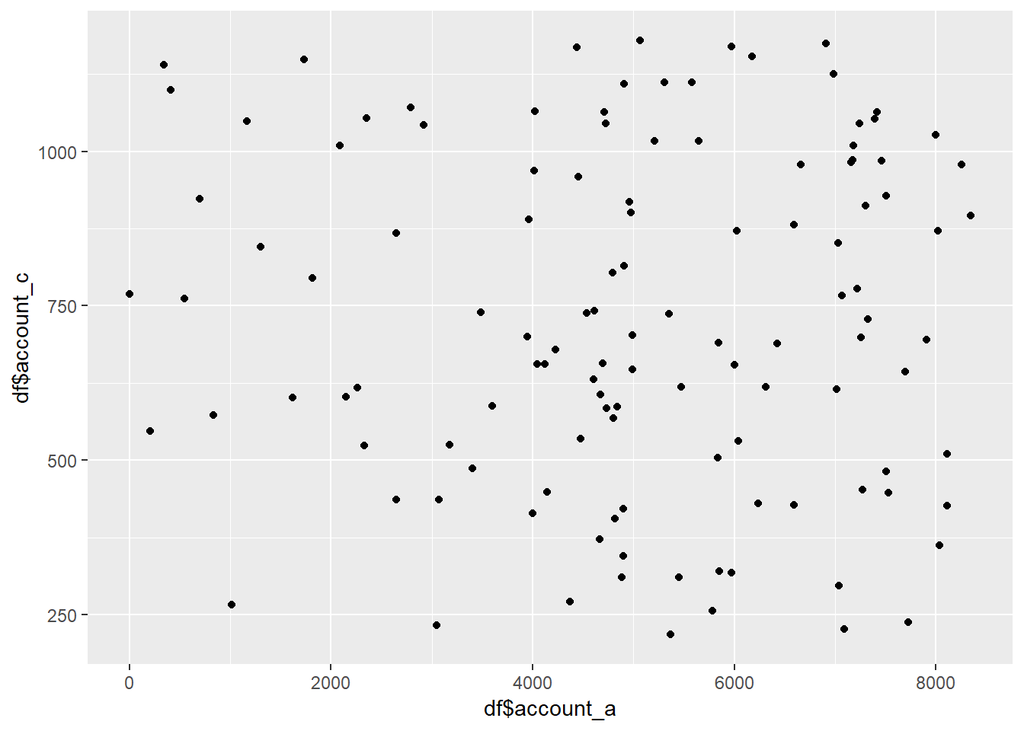

```r
ggplot(df)+
  geom_point(aes(x=df$account_a,y=df$account_c))
```

```r
cor(df$account_a, df$account_c)
```

```
## [1] -0.02937619
```

There’s no correlation between “account_a”" and “account_c”. Function “cor” showed very low negative number = -0.02937619.

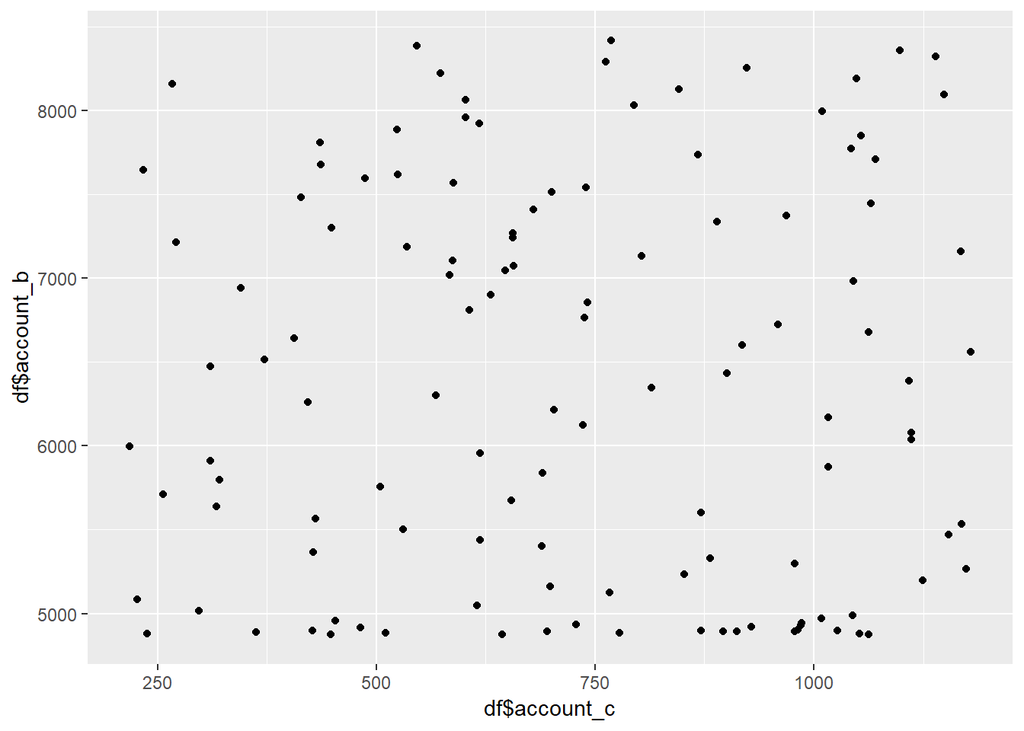

```r
ggplot(df)+
  geom_point(aes(x=df$account_c,y=df$account_b))
```

```r
cor(df$account_c, df$account_b)
```

```
## [1] 0.005483397
```

```r
df_copy<-df
df_copy$time<-as.Date(df$time, format="%Y-%m-%d")
class(df_copy$time)
```

```
## [1] "Date"
```

Now, let’s select the 2016 records and sort them in descending order by time. For that we will need function filter from library “dplyr.

```r
library(dplyr)
library(reshape2)
#*  select(): choosing a subset of columns
#*  filter(): choosing a subset of rows
accounts_2016<- df_copy %>%
  filter(time >= "2016-01-01" & time <="2016-12-01") %>%
  arrange(desc(time))%>%
  melt(id="time") #transform to long format based in time
```

Build a single plot which will show how balance changed for all 3 accounts during that year. Use line plot for this task. (Each account should have different color).

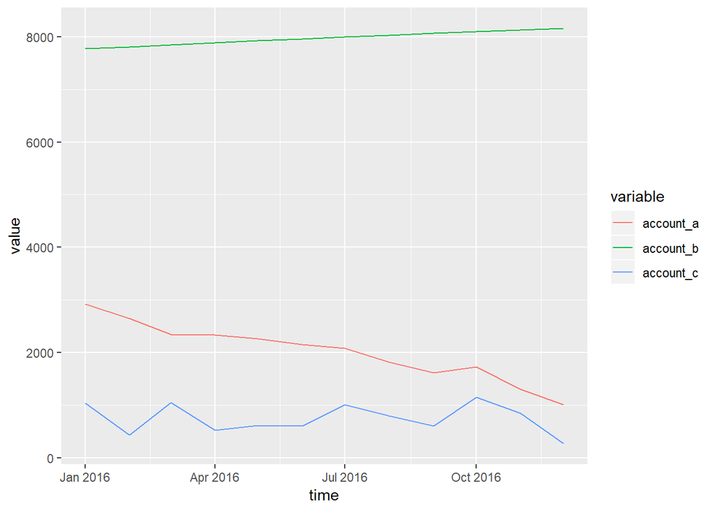

```r
ggplot(accounts_2016, aes(x=time, y=value))+
            geom_line(aes(color=variable))
```

Task #5. Group data by the year, for each year and account calculate average balance. To do it we need to use function format() extract year from the time column.

```r
#class(accounts$time)
df_copy$time<-format(df_copy$time,"%Y")
grouped_data = group_by(df_copy, time)
summary<-summarise(grouped_data, mean(account_a), mean(account_b), mean(account_c))
summary
```

| time | mean(account_a) | mean(account_b) | mean(account_c) |
| --- | --- | --- | --- |
| 2007 | 8008.3199 | 4896.288 | 755.0574 |
| 2008 | 7680.8515 | 4884.911 | 738.6860 |
| 2009 | 7237.8417 | 4985.814 | 710.0840 |
| 2010 | 6578.4392 | 5349.412 | 858.2025 |
| 2011 | 5790.0409 | 5776.445 | 517.3271 |
| 2012 | 5038.8638 | 6278.832 | 764.6492 |
| 2013 | 4731.9239 | 6789.986 | 768.0830 |
| 2014 | 4406.4844 | 7202.973 | 690.6985 |
| 2015 | 3451.1909 | 7579.700 | 650.5849 |
| 2016 | 2018.5251 | 7973.376 | 745.3443 |

[output cut: 1 more lines]

```r
summary<-melt(summary,id="time")
```

Build a heat map to see how average balance changed on each account during the years. What can you say based on the plotted heat map?

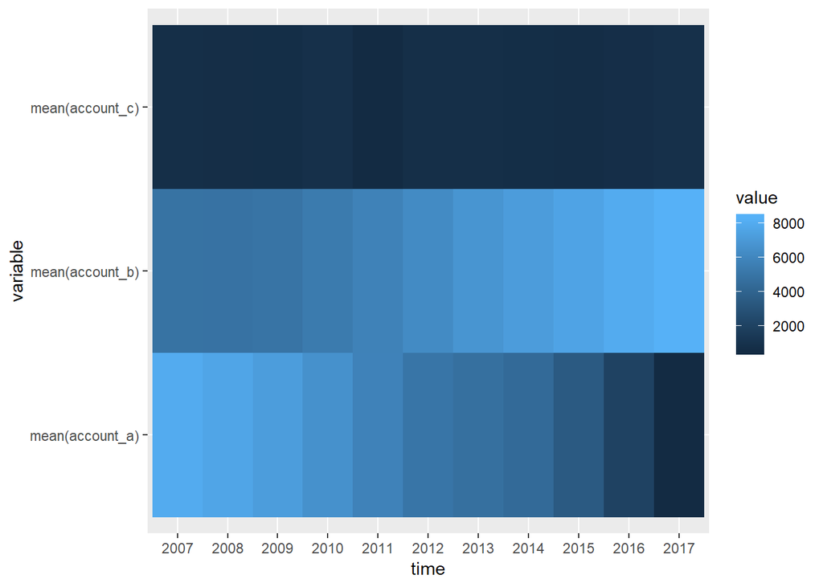

```r
ggplot(summary, aes(x=time, y=variable))+
  geom_tile(aes(fill=value))
```

Write at least 3 observations from the heatmap. 1. The average balance of account c hasn’t changed significantly for the past 10 years. 2. The average balance of account b increased over the 10 years. 3. The average balance of account a decreased for the past 10 years. 4. Heatmap also shows a negative correlation between account a and account b.